# Lab 6: Variable Selection and Regularization

Author

Diya Patel

GitHub Link: https://github.com/diyapatel040124/GSB-544-Computing-and-Machine-Learning/blob/main/Lab_6.html

Part I: Different Model Specs

```python
import pandas as pd
import numpy as np
from sklearn.pipeline import Pipeline
from sklearn.compose import make_column_selector, ColumnTransformer
from sklearn.preprocessing import StandardScaler, OneHotEncoder, PolynomialFeatures
from sklearn.linear_model import LinearRegression, Ridge, Lasso, ElasticNet
from sklearn.model_selection import train_test_split, cross_val_score
from sklearn.metrics import r2_score, mean_squared_error
```

A. Regression with regularization

1. Create a pipeline that includes all the columns as predictors for Salary, and performs ordinary linear regression
2. Fit this pipeline to the full dataset, and interpret a few of the most important coefficients.
3. Use cross-validation to estimate the MSE you would expect if you used this pipeline to predict 1989 salaries.

```python
import pandas as pd
df = pd.read_csv('Hitters.csv')
df.head()
```

|  | AtBat | Hits | HmRun | Runs | RBI | Walks | Years | CAtBat | CHits | CHmRun | CRuns | CRBI | CWalks | League | Division | PutOuts | Assists | Errors | Salary | NewLeague |
| --- | --- | --- | --- | --- | --- | --- | --- | --- | --- | --- | --- | --- | --- | --- | --- | --- | --- | --- | --- | --- |
| 0 | 293 | 66 | 1 | 30 | 29 | 14 | 1 | 293 | 66 | 1 | 30 | 29 | 14 | A | E | 446 | 33 | 20 | NaN | A |
| 1 | 315 | 81 | 7 | 24 | 38 | 39 | 14 | 3449 | 835 | 69 | 321 | 414 | 375 | N | W | 632 | 43 | 10 | 475.0 | N |
| 2 | 479 | 130 | 18 | 66 | 72 | 76 | 3 | 1624 | 457 | 63 | 224 | 266 | 263 | A | W | 880 | 82 | 14 | 480.0 | A |
| 3 | 496 | 141 | 20 | 65 | 78 | 37 | 11 | 5628 | 1575 | 225 | 828 | 838 | 354 | N | E | 200 | 11 | 3 | 500.0 | N |
| 4 | 321 | 87 | 10 | 39 | 42 | 30 | 2 | 396 | 101 | 12 | 48 | 46 | 33 | N | E | 805 | 40 | 4 | 91.5 | N |

```python
# dummify the categorical variables
league_dummy = pd.get_dummies(df['League'], prefix = 'league')
division_dummy = pd.get_dummies(df['Division'], prefix = 'division')
newleague_dummy = pd.get_dummies(df['NewLeague'], prefix = 'newleague')
df = pd.concat([df, league_dummy, division_dummy, newleague_dummy], axis=1)
df
```

|  | AtBat | Hits | HmRun | Runs | RBI | Walks | Years | CAtBat | CHits | CHmRun | ... | Assists | Errors | Salary | NewLeague | league_A | league_N | division_E | division_W | newleague_A | newleague_N |
| --- | --- | --- | --- | --- | --- | --- | --- | --- | --- | --- | --- | --- | --- | --- | --- | --- | --- | --- | --- | --- | --- |
| 0 | 293 | 66 | 1 | 30 | 29 | 14 | 1 | 293 | 66 | 1 | ... | 33 | 20 | NaN | A | True | False | True | False | True | False |
| 1 | 315 | 81 | 7 | 24 | 38 | 39 | 14 | 3449 | 835 | 69 | ... | 43 | 10 | 475.0 | N | False | True | False | True | False | True |
| 2 | 479 | 130 | 18 | 66 | 72 | 76 | 3 | 1624 | 457 | 63 | ... | 82 | 14 | 480.0 | A | True | False | False | True | True | False |
| 3 | 496 | 141 | 20 | 65 | 78 | 37 | 11 | 5628 | 1575 | 225 | ... | 11 | 3 | 500.0 | N | False | True | True | False | False | True |
| 4 | 321 | 87 | 10 | 39 | 42 | 30 | 2 | 396 | 101 | 12 | ... | 40 | 4 | 91.5 | N | False | True | True | False | False | True |
| ... | ... | ... | ... | ... | ... | ... | ... | ... | ... | ... | ... | ... | ... | ... | ... | ... | ... | ... | ... | ... | ... |
| 317 | 497 | 127 | 7 | 65 | 48 | 37 | 5 | 2703 | 806 | 32 | ... | 9 | 3 | 700.0 | N | False | True | True | False | False | True |
| 318 | 492 | 136 | 5 | 76 | 50 | 94 | 12 | 5511 | 1511 | 39 | ... | 381 | 20 | 875.0 | A | True | False | True | False | True | False |
| 319 | 475 | 126 | 3 | 61 | 43 | 52 | 6 | 1700 | 433 | 7 | ... | 113 | 7 | 385.0 | A | True | False | False | True | True | False |
| 320 | 573 | 144 | 9 | 85 | 60 | 78 | 8 | 3198 | 857 | 97 | ... | 131 | 12 | 960.0 | A | True | False | True | False | True | False |
| 321 | 631 | 170 | 9 | 77 | 44 | 31 | 11 | 4908 | 1457 | 30 | ... | 4 | 3 | 1000.0 | A | True | False | False | True | True | False |

322 rows × 26 columns

```python
# Get rid of columns with mostly NaN values
good_cols = df.isna().sum() < 100
df = df.loc[:,good_cols]

# Drop other NAs
df = df.dropna()

df
```

|  | AtBat | Hits | HmRun | Runs | RBI | Walks | Years | CAtBat | CHits | CHmRun | ... | Assists | Errors | Salary | NewLeague | league_A | league_N | division_E | division_W | newleague_A | newleague_N |
| --- | --- | --- | --- | --- | --- | --- | --- | --- | --- | --- | --- | --- | --- | --- | --- | --- | --- | --- | --- | --- | --- |
| 1 | 315 | 81 | 7 | 24 | 38 | 39 | 14 | 3449 | 835 | 69 | ... | 43 | 10 | 475.0 | N | False | True | False | True | False | True |
| 2 | 479 | 130 | 18 | 66 | 72 | 76 | 3 | 1624 | 457 | 63 | ... | 82 | 14 | 480.0 | A | True | False | False | True | True | False |
| 3 | 496 | 141 | 20 | 65 | 78 | 37 | 11 | 5628 | 1575 | 225 | ... | 11 | 3 | 500.0 | N | False | True | True | False | False | True |
| 4 | 321 | 87 | 10 | 39 | 42 | 30 | 2 | 396 | 101 | 12 | ... | 40 | 4 | 91.5 | N | False | True | True | False | False | True |
| 5 | 594 | 169 | 4 | 74 | 51 | 35 | 11 | 4408 | 1133 | 19 | ... | 421 | 25 | 750.0 | A | True | False | False | True | True | False |
| ... | ... | ... | ... | ... | ... | ... | ... | ... | ... | ... | ... | ... | ... | ... | ... | ... | ... | ... | ... | ... | ... |
| 317 | 497 | 127 | 7 | 65 | 48 | 37 | 5 | 2703 | 806 | 32 | ... | 9 | 3 | 700.0 | N | False | True | True | False | False | True |
| 318 | 492 | 136 | 5 | 76 | 50 | 94 | 12 | 5511 | 1511 | 39 | ... | 381 | 20 | 875.0 | A | True | False | True | False | True | False |
| 319 | 475 | 126 | 3 | 61 | 43 | 52 | 6 | 1700 | 433 | 7 | ... | 113 | 7 | 385.0 | A | True | False | False | True | True | False |
| 320 | 573 | 144 | 9 | 85 | 60 | 78 | 8 | 3198 | 857 | 97 | ... | 131 | 12 | 960.0 | A | True | False | True | False | True | False |
| 321 | 631 | 170 | 9 | 77 | 44 | 31 | 11 | 4908 | 1457 | 30 | ... | 4 | 3 | 1000.0 | A | True | False | False | True | True | False |

263 rows × 26 columns

```python
X = df.drop(["Salary"], axis = 1)
y = df["Salary"]
```

```python
X
```

|  | AtBat | Hits | HmRun | Runs | RBI | Walks | Years | CAtBat | CHits | CHmRun | ... | PutOuts | Assists | Errors | NewLeague | league_A | league_N | division_E | division_W | newleague_A | newleague_N |
| --- | --- | --- | --- | --- | --- | --- | --- | --- | --- | --- | --- | --- | --- | --- | --- | --- | --- | --- | --- | --- | --- |
| 1 | 315 | 81 | 7 | 24 | 38 | 39 | 14 | 3449 | 835 | 69 | ... | 632 | 43 | 10 | N | False | True | False | True | False | True |
| 2 | 479 | 130 | 18 | 66 | 72 | 76 | 3 | 1624 | 457 | 63 | ... | 880 | 82 | 14 | A | True | False | False | True | True | False |
| 3 | 496 | 141 | 20 | 65 | 78 | 37 | 11 | 5628 | 1575 | 225 | ... | 200 | 11 | 3 | N | False | True | True | False | False | True |
| 4 | 321 | 87 | 10 | 39 | 42 | 30 | 2 | 396 | 101 | 12 | ... | 805 | 40 | 4 | N | False | True | True | False | False | True |
| 5 | 594 | 169 | 4 | 74 | 51 | 35 | 11 | 4408 | 1133 | 19 | ... | 282 | 421 | 25 | A | True | False | False | True | True | False |
| ... | ... | ... | ... | ... | ... | ... | ... | ... | ... | ... | ... | ... | ... | ... | ... | ... | ... | ... | ... | ... | ... |
| 317 | 497 | 127 | 7 | 65 | 48 | 37 | 5 | 2703 | 806 | 32 | ... | 325 | 9 | 3 | N | False | True | True | False | False | True |
| 318 | 492 | 136 | 5 | 76 | 50 | 94 | 12 | 5511 | 1511 | 39 | ... | 313 | 381 | 20 | A | True | False | True | False | True | False |
| 319 | 475 | 126 | 3 | 61 | 43 | 52 | 6 | 1700 | 433 | 7 | ... | 37 | 113 | 7 | A | True | False | False | True | True | False |
| 320 | 573 | 144 | 9 | 85 | 60 | 78 | 8 | 3198 | 857 | 97 | ... | 1314 | 131 | 12 | A | True | False | True | False | True | False |
| 321 | 631 | 170 | 9 | 77 | 44 | 31 | 11 | 4908 | 1457 | 30 | ... | 408 | 4 | 3 | A | True | False | False | True | True | False |

263 rows × 25 columns

```python
ct = ColumnTransformer(
    [
        ("dummify",
        OneHotEncoder(sparse_output=False, handle_unknown='ignore'),
        make_column_selector(dtype_include=object)),
        ("standardize",
        StandardScaler(),
        make_column_selector(dtype_include=np.number))
    ],
    remainder = "passthrough"
).set_output(transform="pandas")
```

```python
# fit the column transformer
ct.fit(X)
```

```
ColumnTransformer(remainder='passthrough',
                  transformers=[('dummify',
                                 OneHotEncoder(handle_unknown='ignore',
                                               sparse_output=False),
                                 <sklearn.compose._column_transformer.make_column_selector object at 0x1532647d0>),
                                ('standardize', StandardScaler(),
                                 <sklearn.compose._column_transformer.make_column_selector object at 0x111d5e630>)])
```

```python
# transform the column transformer
ct.transform(X)
```

|  | dummify__League_A | dummify__League_N | dummify__Division_E | dummify__Division_W | dummify__NewLeague_A | dummify__NewLeague_N | standardize__AtBat | standardize__Hits | standardize__HmRun | standardize__Runs | ... | standardize__CWalks | standardize__PutOuts | standardize__Assists | standardize__Errors | remainder__league_A | remainder__league_N | remainder__division_E | remainder__division_W | remainder__newleague_A | remainder__newleague_N |
| --- | --- | --- | --- | --- | --- | --- | --- | --- | --- | --- | --- | --- | --- | --- | --- | --- | --- | --- | --- | --- | --- |
| 1 | 0.0 | 1.0 | 0.0 | 1.0 | 0.0 | 1.0 | -0.602900 | -0.595675 | -0.528551 | -1.206112 | ... | 0.435334 | 1.221499 | -0.523191 | 0.213352 | False | True | False | True | False | True |
| 2 | 1.0 | 0.0 | 0.0 | 1.0 | 1.0 | 0.0 | 0.512542 | 0.492260 | 0.729966 | 0.441515 | ... | 0.010373 | 2.109109 | -0.253863 | 0.819964 | True | False | False | True | True | False |
| 3 | 0.0 | 1.0 | 1.0 | 0.0 | 0.0 | 1.0 | 0.628167 | 0.736490 | 0.958788 | 0.402286 | ... | 0.355654 | -0.324661 | -0.744179 | -0.848219 | False | True | True | False | False | True |
| 4 | 0.0 | 1.0 | 1.0 | 0.0 | 0.0 | 1.0 | -0.562092 | -0.462459 | -0.185319 | -0.617673 | ... | -0.862315 | 1.840678 | -0.543909 | -0.696566 | False | True | True | False | False | True |
| 5 | 1.0 | 0.0 | 0.0 | 1.0 | 1.0 | 0.0 | 1.294712 | 1.358167 | -0.871783 | 0.755349 | ... | -0.251434 | -0.031177 | 2.087225 | 2.488147 | True | False | False | True | True | False |
| ... | ... | ... | ... | ... | ... | ... | ... | ... | ... | ... | ... | ... | ... | ... | ... | ... | ... | ... | ... | ... | ... |
| 317 | 0.0 | 1.0 | 1.0 | 0.0 | 0.0 | 1.0 | 0.634968 | 0.425651 | -0.528551 | 0.402286 | ... | -0.463914 | 0.122723 | -0.757991 | -0.848219 | False | True | True | False | False | True |
| 318 | 1.0 | 0.0 | 1.0 | 0.0 | 1.0 | 0.0 | 0.600961 | 0.625476 | -0.757373 | 0.833807 | ... | 2.332483 | 0.079774 | 1.810990 | 1.729882 | True | False | True | False | True | False |
| 319 | 1.0 | 0.0 | 0.0 | 1.0 | 1.0 | 0.0 | 0.485336 | 0.403449 | -0.986194 | 0.245369 | ... | -0.433560 | -0.908051 | -0.039781 | -0.241607 | True | False | False | True | True | False |
| 320 | 1.0 | 0.0 | 1.0 | 0.0 | 1.0 | 0.0 | 1.151881 | 0.803098 | -0.299730 | 1.186870 | ... | 0.272180 | 3.662427 | 0.084525 | 0.516658 | True | False | True | False | True | False |
| 321 | 1.0 | 0.0 | 0.0 | 1.0 | 1.0 | 0.0 | 1.546366 | 1.380370 | -0.299730 | 0.873036 | ... | -0.042747 | 0.419786 | -0.792520 | -0.848219 | True | False | False | True | True | False |

263 rows × 28 columns

```python
# create the pipeline
lr_pipeline_1 = Pipeline(
    [("preprocessing", ct),
    ("linear_regression", LinearRegression())]
)
```

```python
-cross_val_score(lr_pipeline_1, X, y, cv=5, scoring='neg_mean_squared_error')
```

```
array([ 76408.91409134, 129937.76968228,  79976.48830477, 204818.01839674,
       114540.36111572])
```

```python
# fit the pipeline
lr_pipeline_1_fitted = lr_pipeline_1.fit(X,y)
lr_pipeline_1_fitted
```

```
Pipeline(steps=[('preprocessing',
                 ColumnTransformer(remainder='passthrough',
                                   transformers=[('dummify',
                                                  OneHotEncoder(handle_unknown='ignore',
                                                                sparse_output=False),
                                                  <sklearn.compose._column_transformer.make_column_selector object at 0x1532647d0>),
                                                 ('standardize',
                                                  StandardScaler(),
                                                  <sklearn.compose._column_transformer.make_column_selector object at 0x111d5e630>)])),
                ('linear_regression', LinearRegression())])
```

```python
coef_linear = lr_pipeline_1_fitted.named_steps['linear_regression'].coef_
lr_coef_names = lr_pipeline_1_fitted.named_steps["preprocessing"].get_feature_names_out()
lr_coef_df = pd.DataFrame({"Variable": lr_coef_names, "Coef": coef_linear})
lr_coef_df.sort_values(by = "Coef", ascending=False).head(10)
```

|  | Variable | Coef |
| --- | --- | --- |
| 16 | standardize__CRuns | 480.747135 |
| 7 | standardize__Hits | 337.830479 |
| 17 | standardize__CRBI | 260.689886 |
| 11 | standardize__Walks | 135.073897 |
| 14 | standardize__CHits | 86.687617 |
| 19 | standardize__PutOuts | 78.761296 |
| 20 | standardize__Assists | 53.732490 |
| 8 | standardize__HmRun | 37.853837 |
| 24 | remainder__division_E | 29.212311 |
| 2 | dummify__Division_E | 29.212311 |

Most important coefficients: CRuns, Hits, CRBI, Walks, CHits Since all the variables are prefixed with standardize_, each coefficient shows how much the predicted target changes when that feature increases by 1 standard deviation. CRuns: A one SD increase in career runs is associated with a $480.7 increase in the predicted target. Hits: A 1 SD increase in hits has a $337.8 increase. CRBI: A 1 SD increase in career RBIs increases predicted target by $260.7 Walks: A 1 SD increase in walks increases predicted target by $135.1 CHits: A 1 SD increase in career hits increases predicted target by $86.7

```python
ct_poly = ColumnTransformer(
    [
        ("dummify",
        OneHotEncoder(sparse_output=False, handle_unknown='ignore'),
        make_column_selector(dtype_exclude=np.number)),
        ("polynomial", PolynomialFeatures(degree = 2),
        make_column_selector(dtype_include=np.number))
    ],
    remainder = "passthrough"
).set_output(transform="pandas")
```

```python
ct_poly.fit(X)
```

```
ColumnTransformer(remainder='passthrough',
                  transformers=[('dummify',
                                 OneHotEncoder(handle_unknown='ignore',
                                               sparse_output=False),
                                 <sklearn.compose._column_transformer.make_column_selector object at 0x153004890>),
                                ('polynomial', PolynomialFeatures(),
                                 <sklearn.compose._column_transformer.make_column_selector object at 0x153005cd0>)])
```

```python
ct_poly.transform(X)
```

|  | dummify__League_A | dummify__League_N | dummify__Division_E | dummify__Division_W | dummify__NewLeague_A | dummify__NewLeague_N | dummify__league_A_False | dummify__league_A_True | dummify__league_N_False | dummify__league_N_True | ... | polynomial__CWalks^2 | polynomial__CWalks PutOuts | polynomial__CWalks Assists | polynomial__CWalks Errors | polynomial__PutOuts^2 | polynomial__PutOuts Assists | polynomial__PutOuts Errors | polynomial__Assists^2 | polynomial__Assists Errors | polynomial__Errors^2 |
| --- | --- | --- | --- | --- | --- | --- | --- | --- | --- | --- | --- | --- | --- | --- | --- | --- | --- | --- | --- | --- | --- |
| 1 | 0.0 | 1.0 | 0.0 | 1.0 | 0.0 | 1.0 | 1.0 | 0.0 | 0.0 | 1.0 | ... | 140625.0 | 237000.0 | 16125.0 | 3750.0 | 399424.0 | 27176.0 | 6320.0 | 1849.0 | 430.0 | 100.0 |
| 2 | 1.0 | 0.0 | 0.0 | 1.0 | 1.0 | 0.0 | 0.0 | 1.0 | 1.0 | 0.0 | ... | 69169.0 | 231440.0 | 21566.0 | 3682.0 | 774400.0 | 72160.0 | 12320.0 | 6724.0 | 1148.0 | 196.0 |
| 3 | 0.0 | 1.0 | 1.0 | 0.0 | 0.0 | 1.0 | 1.0 | 0.0 | 0.0 | 1.0 | ... | 125316.0 | 70800.0 | 3894.0 | 1062.0 | 40000.0 | 2200.0 | 600.0 | 121.0 | 33.0 | 9.0 |
| 4 | 0.0 | 1.0 | 1.0 | 0.0 | 0.0 | 1.0 | 1.0 | 0.0 | 0.0 | 1.0 | ... | 1089.0 | 26565.0 | 1320.0 | 132.0 | 648025.0 | 32200.0 | 3220.0 | 1600.0 | 160.0 | 16.0 |
| 5 | 1.0 | 0.0 | 0.0 | 1.0 | 1.0 | 0.0 | 0.0 | 1.0 | 1.0 | 0.0 | ... | 37636.0 | 54708.0 | 81674.0 | 4850.0 | 79524.0 | 118722.0 | 7050.0 | 177241.0 | 10525.0 | 625.0 |
| ... | ... | ... | ... | ... | ... | ... | ... | ... | ... | ... | ... | ... | ... | ... | ... | ... | ... | ... | ... | ... | ... |
| 317 | 0.0 | 1.0 | 1.0 | 0.0 | 0.0 | 1.0 | 1.0 | 0.0 | 0.0 | 1.0 | ... | 19044.0 | 44850.0 | 1242.0 | 414.0 | 105625.0 | 2925.0 | 975.0 | 81.0 | 27.0 | 9.0 |
| 318 | 1.0 | 0.0 | 1.0 | 0.0 | 1.0 | 0.0 | 0.0 | 1.0 | 1.0 | 0.0 | ... | 765625.0 | 273875.0 | 333375.0 | 17500.0 | 97969.0 | 119253.0 | 6260.0 | 145161.0 | 7620.0 | 400.0 |
| 319 | 1.0 | 0.0 | 0.0 | 1.0 | 1.0 | 0.0 | 0.0 | 1.0 | 1.0 | 0.0 | ... | 21316.0 | 5402.0 | 16498.0 | 1022.0 | 1369.0 | 4181.0 | 259.0 | 12769.0 | 791.0 | 49.0 |
| 320 | 1.0 | 0.0 | 1.0 | 0.0 | 1.0 | 0.0 | 0.0 | 1.0 | 1.0 | 0.0 | ... | 110224.0 | 436248.0 | 43492.0 | 3984.0 | 1726596.0 | 172134.0 | 15768.0 | 17161.0 | 1572.0 | 144.0 |
| 321 | 1.0 | 0.0 | 0.0 | 1.0 | 1.0 | 0.0 | 0.0 | 1.0 | 1.0 | 0.0 | ... | 62001.0 | 101592.0 | 996.0 | 747.0 | 166464.0 | 1632.0 | 1224.0 | 16.0 | 12.0 | 9.0 |

263 rows × 171 columns

```python
poly_pipeline = Pipeline(
    [("preprocessing", ct_poly),
    ("linear_regression", LinearRegression())]
)
```

```python
from numpy import mean
mse_scores = cross_val_score(poly_pipeline, X, y, cv = 5, scoring = 'neg_mean_squared_error')
print('Linear - CV MSE (mean):', -mean(mse_scores))
```

```
Linear - CV MSE (mean): 696475.7236680366
```

```python
poly_pipeline_fitted = poly_pipeline.fit(X, y)
poly_pipeline_fitted
```

```
Pipeline(steps=[('preprocessing',
                 ColumnTransformer(remainder='passthrough',
                                   transformers=[('dummify',
                                                  OneHotEncoder(handle_unknown='ignore',
                                                                sparse_output=False),
                                                  <sklearn.compose._column_transformer.make_column_selector object at 0x153004890>),
                                                 ('polynomial',
                                                  PolynomialFeatures(),
                                                  <sklearn.compose._column_transformer.make_column_selector object at 0x153005cd0>)])),
                ('linear_regression', LinearRegression())])
```

B. Ridge Regression

1. Create a pipeline that includes all the columns as predictors for Salary, and performs ordinary ridge regression
2. Use cross-validation to tune the alpha hyperparameter
3. Fit the pipeline with your chosen lambda to the full dataset, and interpret a few of the most import coefficients
4. Report the MSE you would expect if you used this pipeline to predict 1989 salaries.

```python
ridge_pipeline = Pipeline(
    [("preprocessing", ct),
    ("ridge_regression", Ridge(alpha=1))]
)
```

```python
-cross_val_score(ridge_pipeline, X, y, cv = 5, scoring = 'neg_mean_squared_error')
```

```
array([ 76993.46940685, 133578.40566044,  78322.08188605, 197323.08126163,
       109813.46171058])
```

```python
ridge_pipeline_fitted = ridge_pipeline.fit(X, y)
ridge_pipeline_fitted
```

```
Pipeline(steps=[('preprocessing',
                 ColumnTransformer(remainder='passthrough',
                                   transformers=[('dummify',
                                                  OneHotEncoder(handle_unknown='ignore',
                                                                sparse_output=False),
                                                  <sklearn.compose._column_transformer.make_column_selector object at 0x1532647d0>),
                                                 ('standardize',
                                                  StandardScaler(),
                                                  <sklearn.compose._column_transformer.make_column_selector object at 0x111d5e630>)])),
                ('ridge_regression', Ridge(alpha=1))])
```

```python
coef_ridge = ridge_pipeline_fitted.named_steps['ridge_regression'].coef_
ridge_coef_names = ridge_pipeline_fitted.named_steps["preprocessing"].get_feature_names_out()
ridge_coef_df = pd.DataFrame({"Variable": ridge_coef_names, "Coef": coef_ridge})
ridge_coef_df.sort_values(by = "Coef", ascending=False).head(10)
```

|  | Variable | Coef |
| --- | --- | --- |
| 16 | standardize__CRuns | 320.210650 |
| 7 | standardize__Hits | 296.562127 |
| 17 | standardize__CRBI | 160.370155 |
| 14 | standardize__CHits | 126.899495 |
| 11 | standardize__Walks | 124.440241 |
| 19 | standardize__PutOuts | 78.609529 |
| 20 | standardize__Assists | 47.446480 |
| 15 | standardize__CHmRun | 39.080343 |
| 2 | dummify__Division_E | 30.128545 |
| 24 | remainder__division_E | 30.128545 |

Most important coefficients: CRuns, Hits, CRBI, CHits, Walks CRuns: A 1 SD increase in career runs is associated with a $320.21 increase in the predicted target Hits: A 1 SD increase in hits corresponds to a $296.56 increase CRBI: A 1 SD increase in career RBIs increases predicted target by $160.37 CHits: A 1 SD increase career hits increases predicted target by $126.89 Walks: A 1 SD increase in Walks increases predicted target by $124.44

The top 5 coefficients suggests that career performance metrics are the best indicators of salary.

```python
from sklearn.model_selection import GridSearchCV
ridge_pipeline_1 = Pipeline(
    [("preprocessing", ct),
    ("ridge_regression", Ridge())]
).set_output(transform="pandas")

alphas = {'ridge_regression__alpha': np.array([100, 10, 1, 0.1, 0.01])}

gscv_ridge = GridSearchCV(ridge_pipeline_1, param_grid=alphas, cv = 5, scoring = 'neg_mean_squared_error')
```

```python
gscv_ridge_fitted = gscv_ridge.fit(X, y)
gscv_ridge_fitted.cv_results_
print("Ridge - Best params:", gscv_ridge_fitted.best_params_)
print("Ridge - Best CV MSE:", -gscv_ridge_fitted.best_score_)
```

```
Ridge - Best params: {'ridge_regression__alpha': np.float64(1.0)}
Ridge - Best CV MSE: 119206.0999851079
```

Best alpha: 1 Best Cross Validation MSE: 119206.099

```python
ridge_cv_results_ = pd.DataFrame(gscv_ridge_fitted.cv_results_)
ridge_cv_results_
```

|  | mean_fit_time | std_fit_time | mean_score_time | std_score_time | param_ridge_regression__alpha | params | split0_test_score | split1_test_score | split2_test_score | split3_test_score | split4_test_score | mean_test_score | std_test_score | rank_test_score |
| --- | --- | --- | --- | --- | --- | --- | --- | --- | --- | --- | --- | --- | --- | --- |
| 0 | 0.005978 | 0.003456 | 0.002489 | 0.000287 | 100.00 | {'ridge_regression__alpha': 100.0} | -56032.806139 | -167929.499540 | -93397.491777 | -186617.904190 | -98389.405904 | -120473.421510 | 48990.967650 | 4 |
| 1 | 0.006837 | 0.002890 | 0.005752 | 0.002153 | 10.00 | {'ridge_regression__alpha': 10.0} | -69527.282931 | -149646.256625 | -79526.252004 | -192662.502008 | -106642.426282 | -119600.943970 | 45873.713000 | 2 |
| 2 | 0.004145 | 0.001159 | 0.002218 | 0.000057 | 1.00 | {'ridge_regression__alpha': 1.0} | -76993.469407 | -133578.405660 | -78322.081886 | -197323.081262 | -109813.461711 | -119206.099985 | 44385.710998 | 1 |
| 3 | 0.003671 | 0.000322 | 0.002459 | 0.000359 | 0.10 | {'ridge_regression__alpha': 0.1} | -76604.579164 | -130019.225186 | -79712.139621 | -201949.564420 | -113467.259442 | -120350.553567 | 45529.007205 | 3 |
| 4 | 0.003366 | 0.000074 | 0.002515 | 0.000445 | 0.01 | {'ridge_regression__alpha': 0.01} | -76430.332452 | -129928.837279 | -79947.103021 | -204402.653776 | -114409.080415 | -121023.601389 | 46370.162483 | 5 |

C. Lasso Regression

1. Create a pipeline that includes all the columns as predictors for Salary, and performs ordinary ridge regression
2. Use cross-validation to tune the lambda hyperparameter
3. Fit the pipeline with your chosen lambda to the full dataset, and interpret a few of the most important coefficients
4. Report the MSE you would expect if you used this pipeline to predict 1989 salaries.

```python
lasso_pipeline = Pipeline(
    [("preprocessing", ct),
    ("lasso_regression", Lasso(alpha=1))]
)
```

```python
-cross_val_score(lasso_pipeline, X, y, cv = 5, scoring = 'neg_mean_squared_error')
```

```
array([ 75612.35953438, 135042.27974637,  79230.77686666, 198789.25402927,
       110133.56995132])
```

```python
lasso_pipeline_fitted = lasso_pipeline.fit(X, y)
lasso_pipeline_fitted
```

```
Pipeline(steps=[('preprocessing',
                 ColumnTransformer(remainder='passthrough',
                                   transformers=[('dummify',
                                                  OneHotEncoder(handle_unknown='ignore',
                                                                sparse_output=False),
                                                  <sklearn.compose._column_transformer.make_column_selector object at 0x1532647d0>),
                                                 ('standardize',
                                                  StandardScaler(),
                                                  <sklearn.compose._column_transformer.make_column_selector object at 0x111d5e630>)])),
                ('lasso_regression', Lasso(alpha=1))])
```

```python
lasso_coef = lasso_pipeline_fitted.named_steps['lasso_regression'].coef_
lasso_coef_names = lasso_pipeline_fitted.named_steps["preprocessing"].get_feature_names_out()
lasso_coef_df = pd.DataFrame({"Variable": lasso_coef_names, "Coef": lasso_coef})
lasso_coef_df.sort_values(by = "Coef", ascending=False).head(10)
```

|  | Variable | Coef |
| --- | --- | --- |
| 16 | standardize__CRuns | 375.565510 |
| 7 | standardize__Hits | 304.359499 |
| 17 | standardize__CRBI | 192.610932 |
| 11 | standardize__Walks | 120.695271 |
| 2 | dummify__Division_E | 113.479117 |
| 19 | standardize__PutOuts | 78.760365 |
| 20 | standardize__Assists | 41.996679 |
| 15 | standardize__CHmRun | 14.225970 |
| 8 | standardize__HmRun | 11.127023 |
| 24 | remainder__division_E | 0.933852 |

```python
lasso_pipeline_1 = Pipeline(
    [("preprocessing", ct),
    ("lasso_regression", Lasso())]
).set_output(transform="pandas")

alphas = {'lasso_regression__alpha': np.array([100, 10, 1, 0.1, 0.01])}

gscv_lasso = GridSearchCV(lasso_pipeline_1, param_grid=alphas, cv = 5, scoring = 'neg_mean_squared_error')
```

```python
gscv_lasso_fitted = gscv_lasso.fit(X, y)

print("Lasso – Best params:", gscv_lasso_fitted.best_params_)
print("Lasso – Best CV MSE:", -gscv_lasso_fitted.best_score_)
```

```
Lasso – Best params: {'lasso_regression__alpha': np.float64(1.0)}
Lasso – Best CV MSE: 119761.64802560143
```

Best alpha: 1 Best CV MSE: 119761.648

```python
lasso_cv_results_ = pd.DataFrame(gscv_lasso_fitted.cv_results_)
lasso_cv_results_
```

|  | mean_fit_time | std_fit_time | mean_score_time | std_score_time | param_lasso_regression__alpha | params | split0_test_score | split1_test_score | split2_test_score | split3_test_score | split4_test_score | mean_test_score | std_test_score | rank_test_score |
| --- | --- | --- | --- | --- | --- | --- | --- | --- | --- | --- | --- | --- | --- | --- |
| 0 | 0.005221 | 0.001377 | 0.002397 | 0.000173 | 100.00 | {'lasso_regression__alpha': 100.0} | -54935.470973 | -237907.803872 | -147095.877418 | -181117.986922 | -97718.672722 | -143755.162381 | 63686.979668 | 5 |
| 1 | 0.004192 | 0.000285 | 0.002296 | 0.000282 | 10.00 | {'lasso_regression__alpha': 10.0} | -60151.060158 | -162621.020698 | -89356.236064 | -193188.960893 | -103823.382839 | -121828.132130 | 48865.292136 | 4 |
| 2 | 0.006729 | 0.000678 | 0.002479 | 0.000364 | 1.00 | {'lasso_regression__alpha': 1.0} | -75612.359534 | -135042.279746 | -79230.776867 | -198789.254029 | -110133.569951 | -119761.648026 | 45085.410711 | 1 |
| 3 | 0.007401 | 0.000504 | 0.002387 | 0.000079 | 0.10 | {'lasso_regression__alpha': 0.1} | -76353.403150 | -129702.742432 | -79778.636918 | -203967.193559 | -113609.155850 | -120682.226382 | 46272.955372 | 2 |
| 4 | 0.007336 | 0.000405 | 0.002283 | 0.000136 | 0.01 | {'lasso_regression__alpha': 0.01} | -76350.461912 | -129577.192506 | -79978.368517 | -204694.664266 | -114219.269827 | -120963.991405 | 46477.289890 | 3 |

D. Elastic Net

1. Create a pipeline that includes all the columns as predictors for Salary, and performs ordinary ridge regression
2. Use cross-validation to tune the lambda and alpha hyperparameters
3. Fit the pipeline with your chosen hyperparameters to the full dataset, and interpret a few of the most important coefficients.
4. Report the MSE you would expect if you used this pipeline to predict 1989 salaries.

```python
elastic_pipeline = Pipeline(
    [("preprocessing", ct),
    ("elastic_net", ElasticNet(alpha=1, l1_ratio=0.5))]
)
```

```python
-cross_val_score(elastic_pipeline, X, y, cv=5, scoring='neg_mean_squared_error')
```

```
array([ 55567.47493619, 168570.20407039,  94144.08373248, 186288.73255678,
        97859.20834921])
```

```python
elastic_pipeline_fitted = elastic_pipeline.fit(X, y)
elastic_pipeline_fitted
```

```
Pipeline(steps=[('preprocessing',
                 ColumnTransformer(remainder='passthrough',
                                   transformers=[('dummify',
                                                  OneHotEncoder(handle_unknown='ignore',
                                                                sparse_output=False),
                                                  <sklearn.compose._column_transformer.make_column_selector object at 0x1532647d0>),
                                                 ('standardize',
                                                  StandardScaler(),
                                                  <sklearn.compose._column_transformer.make_column_selector object at 0x111d5e630>)])),
                ('elastic_net', ElasticNet(alpha=1))])
```

```python
elastic_coef = elastic_pipeline_fitted.named_steps['elastic_net'].coef_
elastic_coef_names = elastic_pipeline_fitted.named_steps["preprocessing"].get_feature_names_out()
elastic_coef_df = pd.DataFrame({"Variable": elastic_coef_names, "Coef": elastic_coef})
elastic_coef_df.sort_values(by = "Coef", ascending=False).head(15)
```

|  | Variable | Coef |
| --- | --- | --- |
| 19 | standardize__PutOuts | 52.295943 |
| 7 | standardize__Hits | 44.326360 |
| 17 | standardize__CRBI | 43.509038 |
| 16 | standardize__CRuns | 41.717800 |
| 14 | standardize__CHits | 41.129816 |
| 11 | standardize__Walks | 38.495581 |
| 15 | standardize__CHmRun | 36.230012 |
| 9 | standardize__Runs | 28.109994 |
| 13 | standardize__CAtBat | 25.623955 |
| 10 | standardize__RBI | 22.595033 |
| 24 | remainder__division_E | 22.167638 |
| 2 | dummify__Division_E | 22.167562 |
| 18 | standardize__CWalks | 8.835075 |
| 1 | dummify__League_N | 6.342849 |
| 23 | remainder__league_N | 6.342681 |

Most important elastic coefficients: PutOuts, Hits, CRBI, CRuns, CHits PutOuts: A 1 SD increase in career PutOuts increases predicted target by $52.30 Hits: A 1 SD increase in Hits increases predicted target by $44.32 CRBI: A 1 SD increase in career RBIs increases predicted target by $43.51 CRuns: A 1 SD increase in career Runs increases predicted target by $41.72 CHits: A 1 SD increase in career hits increases predicted target by $41.13 These top 5 coefficients suggest that career performance metrics are the best indicators of salary.

```python
from sklearn.model_selection import GridSearchCV

elastic_pipeline_1 = Pipeline(
    [("preprocessing", ct),
    ("elastic_net", ElasticNet())]
).set_output(transform="pandas")

param_grid = {
    "elastic_net__alpha": [1, 10, 100],
    "elastic_net__l1_ratio": np.arange(0.0, 1.2, 0.2)
}

gscv_elastic = GridSearchCV(elastic_pipeline_1, param_grid=param_grid, cv = 5, scoring = 'neg_mean_squared_error')
```

```python
gscv_elastic_fitted = gscv_elastic.fit(X, y)

print("Elastic Net – Best params:", gscv_elastic_fitted.best_params_)
print("Elastic Net – Best CV MSE:", -gscv_elastic_fitted.best_score_)
```

```
Elastic Net – Best params: {'elastic_net__alpha': 1, 'elastic_net__l1_ratio': np.float64(1.0)}
Elastic Net – Best CV MSE: 119761.64802560143
```

Best alpha: 1 Best CV MSE: 119761.64802560143

```python
elastic_cv_results_ = pd.DataFrame(gscv_elastic_fitted.cv_results_)
elastic_cv_results_
```

|  | mean_fit_time | std_fit_time | mean_score_time | std_score_time | param_elastic_net__alpha | param_elastic_net__l1_ratio | params | split0_test_score | split1_test_score | split2_test_score | split3_test_score | split4_test_score | mean_test_score | std_test_score | rank_test_score |
| --- | --- | --- | --- | --- | --- | --- | --- | --- | --- | --- | --- | --- | --- | --- | --- |
| 0 | 0.008626 | 0.000801 | 0.002475 | 0.000236 | 1 | 0.0 | {'elastic_net__alpha': 1, 'elastic_net__l1_rat... | -52269.976873 | -175332.789258 | -101749.896040 | -183413.507217 | -94356.833807 | -121424.600639 | 50300.770033 | 6 |
| 1 | 0.003396 | 0.000089 | 0.002135 | 0.000128 | 1 | 0.2 | {'elastic_net__alpha': 1, 'elastic_net__l1_rat... | -53263.888667 | -172860.428989 | -99024.989002 | -184458.592159 | -95326.190171 | -120986.817797 | 49893.331303 | 5 |
| 2 | 0.003520 | 0.000157 | 0.002204 | 0.000196 | 1 | 0.4 | {'elastic_net__alpha': 1, 'elastic_net__l1_rat... | -54657.940322 | -170116.052242 | -95924.925273 | -185636.819776 | -96828.827993 | -120632.913121 | 49404.261164 | 4 |
| 3 | 0.003509 | 0.000138 | 0.002145 | 0.000146 | 1 | 0.6 | {'elastic_net__alpha': 1, 'elastic_net__l1_rat... | -56652.380143 | -166814.558797 | -92150.164654 | -187042.788670 | -99118.261953 | -120355.630843 | 48806.326057 | 3 |
| 4 | 0.003561 | 0.000141 | 0.002184 | 0.000167 | 1 | 0.8 | {'elastic_net__alpha': 1, 'elastic_net__l1_rat... | -60242.324913 | -161855.469981 | -87243.458107 | -189223.724773 | -103034.317786 | -120319.859112 | 47906.362899 | 2 |
| 5 | 0.006128 | 0.000614 | 0.002180 | 0.000068 | 1 | 1.0 | {'elastic_net__alpha': 1, 'elastic_net__l1_rat... | -75612.359534 | -135042.279746 | -79230.776867 | -198789.254029 | -110133.569951 | -119761.648026 | 45085.410711 | 1 |
| 6 | 0.013016 | 0.005863 | 0.005019 | 0.005019 | 10 | 0.0 | {'elastic_net__alpha': 10, 'elastic_net__l1_ra... | -66355.555445 | -239553.901221 | -158013.348532 | -175862.524611 | -108640.242144 | -149685.114391 | 59092.321105 | 13 |
| 7 | 0.003757 | 0.000322 | 0.002485 | 0.000489 | 10 | 0.2 | {'elastic_net__alpha': 10, 'elastic_net__l1_ra... | -62208.615772 | -230972.594061 | -151324.175533 | -174843.551995 | -105246.512658 | -144919.090004 | 57890.655632 | 12 |
| 8 | 0.003840 | 0.000385 | 0.002455 | 0.000462 | 10 | 0.4 | {'elastic_net__alpha': 10, 'elastic_net__l1_ra... | -57631.116556 | -220516.617386 | -142972.015750 | -174340.398822 | -101332.345186 | -139358.498740 | 56477.932706 | 10 |
| 9 | 0.004537 | 0.002136 | 0.002398 | 0.000251 | 10 | 0.6 | {'elastic_net__alpha': 10, 'elastic_net__l1_ra... | -52987.524575 | -207595.655673 | -132231.780515 | -175053.155724 | -97021.460983 | -132977.915494 | 54827.035243 | 9 |
| 10 | 0.003564 | 0.000144 | 0.002138 | 0.000049 | 10 | 0.8 | {'elastic_net__alpha': 10, 'elastic_net__l1_ra... | -49755.829793 | -191340.747219 | -117608.169008 | -178396.010554 | -93181.644980 | -126056.480311 | 52868.478251 | 8 |
| 11 | 0.003895 | 0.000234 | 0.002142 | 0.000046 | 10 | 1.0 | {'elastic_net__alpha': 10, 'elastic_net__l1_ra... | -60151.060158 | -162621.020698 | -89356.236064 | -193188.960893 | -103823.382839 | -121828.132130 | 48865.292136 | 7 |
| 12 | 0.008146 | 0.000320 | 0.002394 | 0.000315 | 100 | 0.0 | {'elastic_net__alpha': 100, 'elastic_net__l1_r... | -109083.808073 | -314317.727737 | -213277.515182 | -195578.873407 | -141135.522346 | -194678.689349 | 70503.305729 | 18 |
| 13 | 0.003525 | 0.000220 | 0.002144 | 0.000077 | 100 | 0.2 | {'elastic_net__alpha': 100, 'elastic_net__l1_r... | -107852.566773 | -312863.631424 | -212167.328069 | -194690.507232 | -140198.574294 | -193554.521558 | 70390.443796 | 17 |
| 14 | 0.003430 | 0.000251 | 0.002146 | 0.000144 | 100 | 0.4 | {'elastic_net__alpha': 100, 'elastic_net__l1_r... | -105993.242527 | -310600.302235 | -210344.027955 | -193504.352633 | -138747.634829 | -191837.912036 | 70196.358158 | 16 |
| 15 | 0.003308 | 0.000089 | 0.002174 | 0.000244 | 100 | 0.6 | {'elastic_net__alpha': 100, 'elastic_net__l1_r... | -102619.634228 | -306325.584008 | -206831.429278 | -191352.656256 | -136127.195736 | -188651.299901 | 69778.622209 | 15 |
| 16 | 0.003390 | 0.000218 | 0.002227 | 0.000309 | 100 | 0.8 | {'elastic_net__alpha': 100, 'elastic_net__l1_r... | -94666.460005 | -296210.911752 | -198411.145218 | -186588.921321 | -129919.729095 | -181159.433478 | 68804.775001 | 14 |
| 17 | 0.003602 | 0.000315 | 0.002060 | 0.000008 | 100 | 1.0 | {'elastic_net__alpha': 100, 'elastic_net__l1_r... | -54935.470973 | -237907.803872 | -147095.877418 | -181117.986922 | -97718.672722 | -143755.162381 | 63686.979668 | 11 |

Part II. Variable Selection

Based on the above results, decide on: - Which numeric variable is most important - Which five numeric variables are most important - Which categorical variable is most important

For each of the four model specifications, compare the following possible feature sets: 1. Using only the best numeric variable 2. Using only the five best variables 3. Using the five best numeric variables and their interactions with the one best categorical variable

Report which combination of features and model performed best, based on the validation metric of MSE

(Note lambda and alpha must be re-tuned for each feature set.)

Identify important variables Using model coefficients that have been already extracted to rank feature importance

```python
# Best numeric variable for Linear Regression
best_linear_1 = "CRuns"
# Best 5 numeric variables for Linear Regression
best_linear_5 = ["CRuns", "Hits", "CRBI", "CHits", "Walks"]
# best categorical variable for Linear Regression
best_linear_cat = "Division"

# use column transfomer to put in the best linear regression numeric variables
ct_1 = ColumnTransformer(
    transformers=[
        ("num", StandardScaler(), [best_linear_1]),
    ],
    remainder="drop"
)

# use the pipeline
linear_pipeline_1_num = Pipeline([
    ("preprocessing", ct_1),
    ("model", LinearRegression())
])

# report the MSE
mse_lr_1 = -cross_val_score(linear_pipeline_1_num, X, y, cv=5, scoring="neg_mean_squared_error").mean()
mse_lr_1
```

```
np.float64(143812.9359162973)
```

```python
# best numeric for ridge regression
best_ridge_1 = "CRuns"
# five best numerics for ridge regression
best_ridge_5 = ["CRuns", "Hits", "CRBI", "CHits", "Walks"]
# best categorical variable for ridge regression
best_ridge_cat = "Division"

ridge_pipeline_1_num = Pipeline([
    ("preprocessing", ct_1),
    ("ridge", Ridge())
])

gscv_1num_ridge = GridSearchCV(
    ridge_pipeline_1_num,
    param_grid={"ridge__alpha": np.array([100, 10, 1, 0.1, 0.01])},
    cv=5,
    scoring="neg_mean_squared_error"
)

gscv_1num_ridge.fit(X, y)
alpha_ridge_1 = (gscv_1num_ridge.best_params_["ridge__alpha"])
print(alpha_ridge_1)
mse_ridge_1 = (-gscv_1num_ridge.best_score_)
mse_ridge_1
```

```
10.0
```

```
np.float64(143658.51736858883)
```

Best alpha: 10 Best MSE: 143658.51736858883

```python
# best numeric variable for lasso
best_lasso_1 = "CRuns"
# five best numerics for lasso
best_lasso_5 = ["CRuns", "Hits", "CRBI", "PutOuts", "Walks"]
# best categorical variable for lasso
best_lasso_cat = "Division"

alphas = np.array([100, 10, 1, 0.1, 0.01])

lasso_pipeline_1_num = Pipeline([
    ("preprocessing", ct_1),
    ("lasso", Lasso())
])

gscv_1num_lasso = GridSearchCV(
    lasso_pipeline_1_num,
    param_grid={"lasso__alpha": alphas},
    cv = 5,
    scoring = "neg_mean_squared_error"
)

gscv_1num_lasso.fit(X, y)
alpha_lasso_1 = (gscv_1num_lasso.best_params_["lasso__alpha"])
print(alpha_lasso_1)
mse_lasso_1 = (-gscv_1num_lasso.best_score_)
mse_lasso_1
```

```
10.0
```

```
np.float64(143793.4491585397)
```

Best alpha: 10 Best MSE: 143793.4491585397

```python
best_elastic_1 = "PutOuts"
best_elastic_num_5 = ["PutOuts", "Hits", "CRBI", "CRuns", "CHits"]
best_elastic_cat = "Division"

ct_2 = ColumnTransformer(
    transformers=[
        ("num", StandardScaler(), [best_elastic_1]),
    ],
    remainder="drop"
)
elastic_pipeline_1_num = Pipeline([
    ("preprocessing", ct_1),
    ("elastic_net", ElasticNet())
])

param_grid = {
    "elastic_net__alpha": [1, 10, 100],
    "elastic_net__l1_ratio": np.arange(0.0, 1.2, 0.2)
}

gscv_1num_elastic = GridSearchCV(
    elastic_pipeline_1_num,
    param_grid=param_grid,
    cv=5,
    scoring="neg_mean_squared_error"
)

gscv_1num_elastic.fit(X,y)
alpha_elastic_1 = print(gscv_1num_elastic.best_params_)
mse_elastic_1 = (-gscv_1num_elastic.best_score_)
mse_elastic_1
```

```
{'elastic_net__alpha': 10, 'elastic_net__l1_ratio': np.float64(1.0)}
```

```
np.float64(143793.4491585397)
```

Top 5 numeric variables

```python
ct_5 = ColumnTransformer(
    transformers=[
        ("num", StandardScaler(), best_linear_5),
    ],
    remainder="drop"
)
linear_pipeline_5_num = Pipeline([
    ("preprocessing", ct_5),
    ("model", LinearRegression())
])

mse_lr_5= -cross_val_score(linear_pipeline_5_num, X, y, cv=5, scoring="neg_mean_squared_error").mean()

mse_lr_5
```

```
np.float64(126047.77085146759)
```

MSE: 126047.77085146759

```python
best_ridge_1 = "CRuns"
# five best numerics
best_ridge_5 = ["CRuns", "Hits", "CRBI", "CHits", "Walks"]
# best categorical
best_ridge_cat = "Division"

ridge_pipeline_5_num = Pipeline([
    ("preprocessing", ct_5),
    ("ridge", Ridge())
])

gscv_5num_ridge = GridSearchCV(
    ridge_pipeline_5_num,
    param_grid={"ridge__alpha": np.array([100, 10, 1, 0.1, 0.01])},
    cv=5,
    scoring="neg_mean_squared_error"
)

gscv_5num_ridge.fit(X, y)
alpha_ridge_5 = print(gscv_5num_ridge.best_params_["ridge__alpha"])
mse_ridge_5 = (-gscv_5num_ridge.best_score_)
mse_ridge_5
```

```
100.0
```

```
np.float64(122492.15914539216)
```

Best alpha: 100 Best MSE: 122492.15914539216

```python
best_lasso_1 = "CRuns"
# five best numerics
best_lasso_5 = ["CRuns", "Hits", "CRBI", "PutOuts", "Walks"]
# best categorical
best_lasso_cat = "Division"

alphas = np.array([100, 10, 1, 0.1, 0.01])

ct_lasso = ColumnTransformer(
    transformers=[
        ("num", StandardScaler(), best_lasso_5),
    ],
    remainder="drop"
)

lasso_pipeline_5_num = Pipeline([
    ("preprocessing", ct_lasso),
    ("lasso", Lasso())
])

gscv_5num_lasso = GridSearchCV(
    lasso_pipeline_5_num,
    param_grid={"lasso__alpha": alphas},
    cv = 5,
    scoring = "neg_mean_squared_error"
)

gscv_5num_lasso.fit(X, y)
alpha_lasso_5 = print(gscv_5num_lasso.best_params_["lasso__alpha"])
mse_lasso_5 = (-gscv_5num_lasso.best_score_)
mse_lasso_5
```

```
0.01
```

```
np.float64(121332.46795661622)
```

Best alpha: 0.01 Best MSE: 121332.46795661622

```python
best_elastic_1 = "PutOuts"
best_elastic_num_5 = ["PutOuts", "Hits", "CRBI", "CRuns", "CHits"]
best_elastic_cat = "Division"

ct_elastic = ColumnTransformer(
    transformers=[
        ("num", StandardScaler(), best_elastic_num_5),
    ],
    remainder="drop"
)
elastic_pipeline_5_num = Pipeline([
    ("preprocessing", ct_elastic),
    ("elastic_net", ElasticNet())
])

param_grid = {
    "elastic_net__alpha": [1, 10, 100],
    "elastic_net__l1_ratio": np.arange(0.0, 1.2, 0.2)
}

gscv_5num_elastic = GridSearchCV(
    elastic_pipeline_5_num,
    param_grid=param_grid,
    cv=5,
    scoring="neg_mean_squared_error"
)

gscv_5num_elastic.fit(X,y)
alpha_elastic_5 = print(gscv_5num_elastic.best_params_)
mse_elastic_5 = (-gscv_5num_elastic.best_score_)
mse_elastic_5
```

```
{'elastic_net__alpha': 1, 'elastic_net__l1_ratio': np.float64(0.8)}
```

```
np.float64(121749.16207174162)
```

Best alpha: 1 Best MSE: 121749.16207174162

```python
one_hot = OneHotEncoder(handle_unknown="ignore", sparse_output=False)

ct_5num_1cat = ColumnTransformer(
    transformers=[
        ("num", StandardScaler(), best_linear_5),
        ("cat", one_hot, [best_linear_cat]),
    ],
    remainder="drop"
)

poly_inter = PolynomialFeatures(degree=2, interaction_only=True, include_bias=False)

preprocess_with_interaction = Pipeline([
    ("ct", ct_5num_1cat),
    ("poly", poly_inter)
])

# linear regression
linear_pipeline_5_1 = Pipeline([
    ("preprocessing", preprocess_with_interaction),
    ("model", LinearRegression())
])

mse_lr_5_1 = -cross_val_score(linear_pipeline_5_1, X, y, scoring="neg_mean_squared_error", cv=5).mean()
mse_lr_5_1
```

```
np.float64(155443.56836608454)
```

MSE: 155443.56836608454

```python
ct_ridge_5num_1cat = ColumnTransformer(
    transformers=[
        ("num", StandardScaler(), best_ridge_5),
        ("cat", one_hot, [best_ridge_cat]),
    ],
    remainder="drop")

preprocess_ridge_with_interaction = Pipeline([
    ("ct", ct_ridge_5num_1cat),
    ("poly", poly_inter)
])

ridge_pipeline_5_1 = Pipeline([
    ("preprocessing", preprocess_ridge_with_interaction),
    ("ridge", Ridge())
])

gscv_5_1_ridge = GridSearchCV(
    ridge_pipeline_5_1,
    param_grid={"ridge__alpha": np.array([100, 10, 1, 0.1, 0.01])},
    cv=5,
    scoring="neg_mean_squared_error"
)

gscv_5_1_ridge.fit(X, y)
alpha_ridge_5_1 = print(gscv_5_1_ridge.best_params_["ridge__alpha"])
mse_ridge_5_1 = (-gscv_5_1_ridge.best_score_)
mse_ridge_5_1
```

```
100.0
```

```
np.float64(100776.67053685356)
```

Best alpha: 100 Best MSE: 100776.670

```python
ct_lasso_5num_1cat = ColumnTransformer(
    transformers=[
        ("num", StandardScaler(), best_lasso_5),
        ("cat", one_hot, [best_lasso_cat]),
    ],
    remainder="drop")

preprocess_lasso_with_interaction = Pipeline([
    ("ct", ct_lasso_5num_1cat),
    ("poly", poly_inter)
])

lasso_pipeline_5_1 = Pipeline([
    ("preprocessing", preprocess_lasso_with_interaction),
    ("lasso", Lasso())
])

alphas = np.array([100, 10, 1, 0.1, 0.01])

gscv_5_1_lasso = GridSearchCV(
    lasso_pipeline_5_1,
    param_grid={"lasso__alpha": alphas},
    cv=5,
    scoring="neg_mean_squared_error"
)

gscv_5_1_lasso.fit(X, y)
alpha_lasso_5_1 = print(gscv_5_1_lasso.best_params_["lasso__alpha"])
mse_lasso_5_1 = (-gscv_5_1_lasso.best_score_)
mse_lasso_5_1
```

```
10.0
```

```
np.float64(94276.86371790859)
```

Best alpha: 10 Best MSE: 94276.86371790859

```python
ct_elastic_5num_1cat = ColumnTransformer(
    transformers=[
        ("num", StandardScaler(), best_elastic_num_5),
        ("cat", one_hot, [best_elastic_cat]),
    ],
    remainder="drop")

preprocess_elastic_with_interaction = Pipeline([
    ("ct", ct_elastic_5num_1cat),
    ("poly", poly_inter)
])

elastic_pipeline_5_1 = Pipeline([
    ("preprocessing", preprocess_elastic_with_interaction),
    ("elastic", ElasticNet())
])

param_grid = {
    "elastic__alpha": [1, 10, 100],
    "elastic__l1_ratio": np.arange(0.0, 1.2, 0.2)
}

gscv_5_1_elastic = GridSearchCV(
    elastic_pipeline_5_1,
    param_grid=param_grid,
    cv=5,
    scoring="neg_mean_squared_error"
)

gscv_5_1_elastic.fit(X, y)
alpha_elastic_5_1 = print(gscv_5_1_elastic.best_params_)
mse_elastic_5_1 = (-gscv_5_1_elastic.best_score_)
mse_elastic_5_1
```

```
{'elastic__alpha': 1, 'elastic__l1_ratio': np.float64(0.2)}
```

```
np.float64(104640.74844849163)
```

Best alpha: 1 Best alpha: 104640.74844849163

```python
results = pd.DataFrame({
    'Model': ['Linear', 'Ridge', 'Lasso', 'ElasticNet'],
    '1num_MSE': [mse_lr_1, mse_ridge_1, mse_lasso_1, mse_elastic_1],
    '5num_MSE': [mse_lr_5, mse_ridge_5, mse_lasso_5, mse_elastic_5],
    '5num+1cat_interact_MSE': [mse_lr_5_1, mse_ridge_5_1, mse_lasso_5_1, mse_elastic_5_1]
})
results
```

|  | Model | 1num_MSE | 5num_MSE | 5num+1cat_interact_MSE |
| --- | --- | --- | --- | --- |
| 0 | Linear | 143812.935916 | 126047.770851 | 155443.568366 |
| 1 | Ridge | 143658.517369 | 122492.159145 | 100776.670537 |
| 2 | Lasso | 143793.449159 | 121332.467957 | 94276.863718 |
| 3 | ElasticNet | 143793.449159 | 121749.162072 | 104640.748448 |

The Lasso model with 5 numerical and 1 categorical variable interaction was the model that performed the best, based on a lower reported MSE value. Part III: Discussion

A. Ridge Compare your Ridge models with your ordinary regression models. How did your coefficients compare? Why does this make sense?

I ran the coefficients for Linear Regression, and since no tuning was required, I just fit the model before getting the standardized coefficients. For Ridge Regression, the model was previously fitted through the GridSearchCV.

Part B: LASSO Compare your LASSO in I with your three LASSO models in II. Did you get the same alpha results? Why does this make sense? Did you get the same MSEs? Why does this make sense?

When using the best numeric, the MSE is much higher because the model is very simple, has underfitting and high error. When using the 5 best numeric variables, the MSE decreases because now there is better fit to capture more variation and lower error as a result. When using the best 5 numeric and 1 categorical, this was shown to have the best fit where the categorical and interaction terms improve predictive power. In the full model form part I the MSE is slightly higher than the best subset, with possible mild overfitting.

The differences between both parts make sense because lasso regression depends on both the number of predictors and their correlations. The full model had correlated variables, so the alpha provided more stability. The reduced models were much simpler and had less multicollinearity, so they had a different level of penalization to minimimze error. Because the MSEs were different, this was due to using fewer predictors which increased bias, while using full amount of predictors reduced bais but increased variance.

C. Elastic Net Compare your MSEs for the Elastic Net models with those for the Ridge and LASSO models. Why does it make sense that Elastic Net always “wins”?

Part IV: Final Model Fit your final best pipeline on the full dataset, and summarize your results in a few short sentences and a plot.

```python
# Refit the final best model on the full dataset
ct_lasso_5num_1cat = ColumnTransformer(
    transformers=[
        ("num", StandardScaler(), best_lasso_5),
        ("cat", one_hot, [best_lasso_cat]),
    ],
    remainder="drop"
)

preprocess_lasso_with_interaction = Pipeline([
    ("ct", ct_lasso_5num_1cat),
    ("poly", poly_inter)
])

# using the best alpha from above
best_alpha_lasso = gscv_5_1_lasso.best_params_['lasso__alpha']

final_lasso_pipe = Pipeline([
    ("preprocessing", preprocess_lasso_with_interaction),
    ("lasso", Lasso(alpha=best_alpha_lasso))
])

# fit the full data set to the pipeline
final_lasso_pipe.fit(X, y)
y_pred = final_lasso_pipe.predict(X)

final_mse = mean_squared_error(y, y_pred)
final_r2 = r2_score(y, y_pred)

print(f"Best alpha: {best_alpha_lasso}")
print(f"Mean Squared Error (MSE): {final_mse}")
print(f"R^2: {final_r2}")
```

```
Best alpha: 10.0
Mean Squared Error (MSE): 72378.95416309132
R^2: 0.6429860898033024
```

Alpha: 10.0, MSE: 72378.95416309132, R^2: 0.6429860898033024

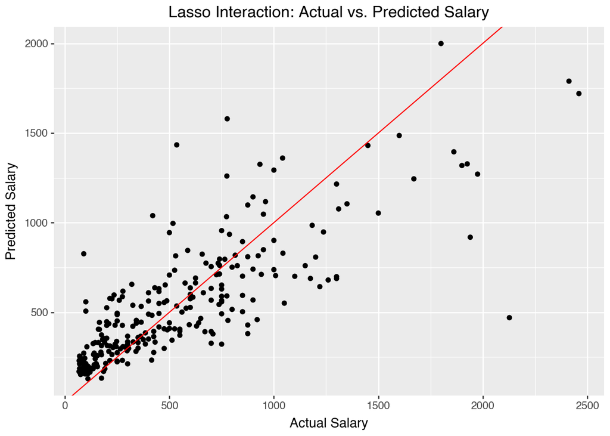

```python
from plotnine import *
df_plot = pd.DataFrame({
    "Actual": y,
    "Predicted": y_pred
})

plot = (
    ggplot(df_plot, aes(x="Actual", y="Predicted"))
    + geom_point()
    + geom_abline(intercept = 0, slope=1, color="red")
    + labs(
        title = "Lasso Interaction: Actual vs. Predicted Salary",
        x = "Actual Salary",
        y = "Predicted Salary"
    )
)

plot
```

I used the Lasso model with interaction and it seemed to perform well on the full dataset. With an alpha value of 10, the model has an MSE od 72,379 and .643 R^2, which means it explains 64% of the variation in player salaries. The plot of the actual vs. predicted salaries shows that most of the points roughly are close to the line. This means that the model’s predictions closely align with the observed values. The higher up the line you go, a few points start to drift more strongly at higher salaries. This also means the model does underestimates extreme values but overall provided a good fit.